# All about cats in R

1/23/2019

## About Me

- Nathan Frey
- nathangfrey@gmail.com
- New to Chicago
- Trying to do freelancing Data Science Work as a career
- Been using R for ~ 6 years

## Cats in R??? What?

[figure not shown]

Really?

## Yup

[figure not shown]

- `cat()` stands for Concatenate and Print
- It’s is a function to output objects to the console
- Doesn’t do as much conversion as `print`. Still powerful

## Using `cat()`

`cat(..., file="catData.txt"" sep= "\n", append=TRUE)`

- args:
  - … - The information to be printed out to the screen
  - file - An optional argument that specifics a file to be created, overwritten, or appended
  - sep - Specifies what separates the printed objects
  - append - Boolean: If a file is to be appended or not, defaults to `FALSE`
- Canonical Examples:
  - http://rfunction.com/archives/1866

## Using `cat()` (con’t)

```r
x<- c(25, 50, 75, 100)
cat(x, sep = " . ")
```

```
## 25 . 50 . 75 . 100
```

```r
cat(x, sep = "\n") # "\n" is a newline character
```

```
## 25
## 50
## 75
## 100
```

## Using `cat()` (con’t)

- More complex data structures such as nested lists don’t work

```r
y <- list(a = c(1, 2, 3), b = list(name = "Bob", age = 55,
    gender = "male"))
# Will fail: cat(y) Instead:
cat(str(y))
```

```
## List of 2
##  $ a: num [1:3] 1 2 3
##  $ b:List of 3
##   ..$ name  : chr "Bob"
##   ..$ age   : num 55
##   ..$ gender: chr "male"
```

## Using `cat()` (con’t)

```r
x <- c(25, 50, 75, 100)
for (i in 1:length(x)) {
    if (i == 1) {
        cat("Starting some operation", "\n")
    }
    cat(paste0("The value in position ", i, " of the object x is ",
        x[i]), "\n")
    if (i == length(x)) {
        cat("Process completed. Processed", length(x), "values",
            "\n")
    }
}
```

```
## Starting some operation
## The value in position 1 of the object x is 25
## The value in position 2 of the object x is 50
## The value in position 3 of the object x is 75
## The value in position 4 of the object x is 100
## Process completed. Processed 4 values
```

## How I most commonly use `cat()` in R…

- Monitoring the progress of `RScript` functions
- Debugging `shiny` applications:
  - https://shiny.rstudio.com/articles/debugging.html
    - see the part about `printf` tracing
    - “In some situations the best tracing technique is the oldest: a statement that emits text to the console when it’s reached. These are more work to use, but offer the unique advantage of allowing you to emit the values of variables without interrupting execution.”
- Demo time

## RScript

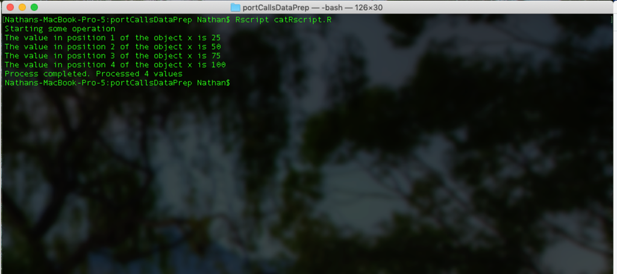

Steps To Run (Mac/Linux):  
1. Copy the `catRscript` code in the appendix into a new file, call it `catRscript.R`  
2. Save the file to your current working directory  
3. Open a terminal window  
4. `cd` to the directory from step 2  
5. Type `Rscript catRscript.R` and press `enter`

## Shiny App

- Live Demo

**To View After Presentation:**

- Code will be uploaded to a seperate folder on GitHub
- Specific instructions will be provided in that folder

## Thank You!

- Questions?

## Appendix

- Code for the `Rscript` example:

```r
x <- c(25, 50, 75, 100)
for (i in 1:length(x)) {
    if (i == 1) {
        cat("Starting some operation", "\n")
    }
    cat(paste0("The value in position ", i, " of the object x is ",
        x[i]), "\n")
    if (i == length(x)) {
        cat("Process completed. Processed", length(x), "values",
            "\n")
    }
    Sys.sleep(2)
}
```